# NSC–>ENB

BioScienceApps

Estefania Mancini

18-21 de abril de 2022

## Tabla de conteos

Luego del alineamiento hay que contar cuántas lecturas han caı́do en cada región de interés y dependerá nuevamente de nuestra pregunta biológica y de la referencia contra la que hayamos decidido alinear.

En nuestro caso, con STAR, usando el parámetro **–quantMode GeneCounts**, por cada alineamiento, también se obtiene un archivo en formato tabular con las lecturas que se superponen a las coordenadas de los genes.

Podemos inspeccionar como fueron las métricas de los alineamientos, usando la herramienta MultiQC: [STARQC](https://estepi.github.io/RNA-Seq_II_esp/STARQC/multiqc_report.html)

# Detección de genes diferencialmente expresados

Una vez que tenemos las tablas de conteos hay que realizar el análisis de los datos para buscar aquellos genes que se hayan comportado diferente en las condicones en estudio.

En este caso, analizaremos datos de un trabajo cuyo objetivo es analizar el impacto sobre la remodelación del transcriptoma durante 2 momentos de la neurodiferenciacición.

La sucesión de estadíos es: NSC–>ENB–>LNB

El diseño experimental es una comparación entre **3 estados o condiciones** , con **3 réplicas** biológicas cada una.

Antes de empezar armamos un archivo *targets* o *mapping file* donde se detalla cada muestra a qué condición corresponde

Empezaremos con una compracion entre 2 condiciones: NSC vs ENB

Cargaremos la tabla de counts a nivel gen. Especificamos algunas opciones tales como cuál es la colunma que le da nombre a las filas *(row.names = 1)*, así como si los nombres de las columnas. Para saber sobre estas especificaciones puede consultar el help de *read.table*.

Cargamos todas los paquetes que usaremos:

```r
library(ggplot2)
library(reshape2)
library(edgeR)
library(ggrepel)
library(org.Mm.eg.db)
```

```r
counts <-
    read.table(
        "/home/alumno01/data/mouse/geneCountsMmu.tab",
        row.names = 1,
        header = T,
        stringsAsFactors = F
    )
```

¿Qué tipo de objeto es **counts**? ¿Qué dimensiones tiene? ¿Cómo luce?

Para explorar un poco la tabla de datos, miremos algunas medidas resumen y la distribucion de los counts:

```r
class(counts)
```

```
## [1] "data.frame"
```

```r
dim(counts)
```

```
## [1] 38924     9
```

```r
head(counts)
```

```
##                    ENB_1 ENB_2 ENB_3 LNB_1 LNB_2 LNB_3 NSC_1 NSC_2 NSC_3
## ENSMUSG00000090025     0     0     0     0     0     0     0     0     0
## ENSMUSG00000064842     0     0     0     0     0     0     0     0     0
## ENSMUSG00000051951    92    27    21    70   130     0    11    60    16
## ENSMUSG00000089699    11     4     7     2     8     0     0     0     0
## ENSMUSG00000088333     0     0     0     0     0     0     0     0     0
## ENSMUSG00000025900     0     0     0     0     0     0     0     0     0
```

```r
summary(counts)
```

```
##      ENB_1              ENB_2             ENB_3              LNB_1
##  Min.   :     0.0   Min.   :    0.0   Min.   :     0.0   Min.   :    0.0
##  1st Qu.:     0.0   1st Qu.:    0.0   1st Qu.:     0.0   1st Qu.:    0.0
##  Median :     0.0   Median :    0.0   Median :     0.0   Median :    0.0
##  Mean   :   206.6   Mean   :  126.8   Mean   :   256.7   Mean   :  134.8
##  3rd Qu.:    64.0   3rd Qu.:   43.0   3rd Qu.:    85.0   3rd Qu.:   60.0
##  Max.   :921527.0   Max.   :50312.0   Max.   :626510.0   Max.   :76274.0
##      LNB_2              LNB_3              NSC_1             NSC_2
##  Min.   :     0.0   Min.   :    0.00   Min.   :    0.0   Min.   :     0.0
##  1st Qu.:     0.0   1st Qu.:    0.00   1st Qu.:    0.0   1st Qu.:     0.0
##  Median :     0.0   Median :    0.00   Median :    0.0   Median :     0.0
##  Mean   :   234.7   Mean   :   99.14   Mean   :  244.8   Mean   :   222.8
##  3rd Qu.:    84.0   3rd Qu.:   45.00   3rd Qu.:  121.0   3rd Qu.:    96.0
##  Max.   :539477.0   Max.   :73152.00   Max.   :69142.0   Max.   :830771.0
##      NSC_3
##  Min.   :    0.0
##  1st Qu.:    0.0
##  Median :    0.0
##  Mean   :  201.4
##  3rd Qu.:  102.0
##  Max.   :60275.0
```

- ¿Cuántos genes fueron mapeados?

# Comparación entra las condiciones **NSC–>ENB**

El primer paso entonces es subsetear la tabla y la podemos reordenar ya de acuerdo a las condiciones a comparar (por practicidad):

```r
dataset1<-counts[,c(7,8,9,1,2,3)]
head(dataset1)
```

```
##                    NSC_1 NSC_2 NSC_3 ENB_1 ENB_2 ENB_3
## ENSMUSG00000090025     0     0     0     0     0     0
## ENSMUSG00000064842     0     0     0     0     0     0
## ENSMUSG00000051951    11    60    16    92    27    21
## ENSMUSG00000089699     0     0     0    11     4     7
## ENSMUSG00000088333     0     0     0     0     0     0
## ENSMUSG00000025900     0     0     0     0     0     0
```

Podemos explorar usando boxplots como es la distribución de los counts en las diferentes muestras:

```r
df<- melt(dataset1)
```

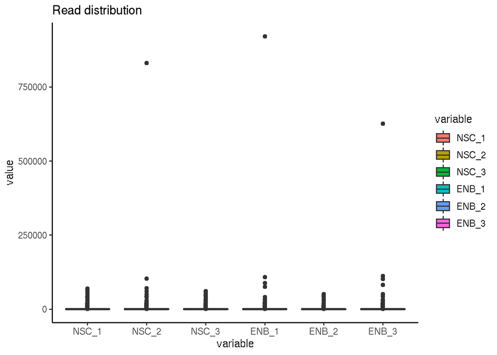

```r
ggplot(df, aes(x=variable, y=value, fill=variable)) +
  geom_boxplot()+
  theme_classic()+
  labs(title="Read distribution")
```

- Hay genes que tienen una cantidad de lecturas extraordinaria. ¿Cuáles son?

```r
highlyExpress<-rowMeans(dataset1)>50000
dataset1[which(highlyExpress),]
```

```
##                    NSC_1  NSC_2 NSC_3  ENB_1 ENB_2  ENB_3
## ENSMUSG00000072235 37545  29687 27791  88642 50312 102301
## ENSMUSG00000098178 14292 830771 20325 921527 44551 626510
## ENSMUSG00000029580 47579  44945 44435  75854 42239  82363
## ENSMUSG00000064339 39261 103343 50443 108438 46165 111668
```

Podemos regraficar excluyendo aquellos genes con > 100000 lecturas por ejemplo:

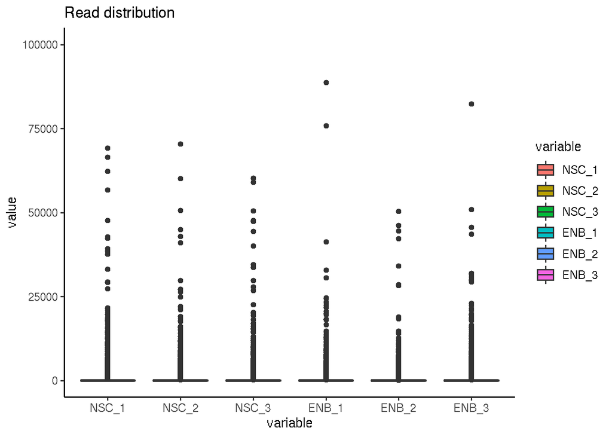

```r
ggplot(df, aes(x=variable, y=value, fill=variable)) +
  geom_boxplot()+
  theme_classic()+
  labs(title="Read distribution")+
  ylim(0, 100000)
```

# Filtros

También podemos probar con diferentes umbrales. No hay una regla estricta, dependerá del experimento en concreto

```r
cpms<-cpm(dataset1)
```

Armamos un nuevo objeto y sobre el realizamos el filtro:

```r
keep<-rowSums(cpms>1)>3
summary(keep)
```

```
##    Mode   FALSE    TRUE
## logical   25643   13281
```

¿Qué tipo de vector es **keep**? ¿Para qué voy a utilizarlo? ¿Qué longitud tiene? ¿Cuántos valores son **TRUE**?

Controlemos la dimensión de la matriz original y filtrada, una vez que subseteamos con el vector **keep**:

```r
dim(counts)
```

```
## [1] 38924     9
```

```r
countsf<-counts[keep,]
dim(countsf)
```

```
## [1] 13281     9
```

Repetimos las medidas resumen y gráficos exploratorios:

```r
summary(countsf)
```

```
##      ENB_1              ENB_2             ENB_3            LNB_1
##  Min.   :     0.0   Min.   :    0.0   Min.   :     0   Min.   :    0
##  1st Qu.:    57.0   1st Qu.:   37.0   1st Qu.:    73   1st Qu.:   50
##  Median :   220.0   Median :  143.0   Median :   284   Median :  162
##  Mean   :   603.7   Mean   :  370.4   Mean   :   750   Mean   :  391
##  3rd Qu.:   554.0   3rd Qu.:  374.0   3rd Qu.:   732   3rd Qu.:  386
##  Max.   :921527.0   Max.   :50312.0   Max.   :626510   Max.   :76274
##      LNB_2              LNB_3             NSC_1           NSC_2
##  Min.   :     0.0   Min.   :    0.0   Min.   :    0   Min.   :     0.0
##  1st Qu.:    73.0   1st Qu.:   36.0   1st Qu.:  105   1st Qu.:    82.0
##  Median :   263.0   Median :  118.0   Median :  325   Median :   267.0
##  Mean   :   683.8   Mean   :  285.4   Mean   :  712   Mean   :   648.4
##  3rd Qu.:   676.0   3rd Qu.:  270.0   3rd Qu.:  737   3rd Qu.:   596.0
##  Max.   :539477.0   Max.   :73152.0   Max.   :69142   Max.   :830771.0
##      NSC_3
##  Min.   :    0
##  1st Qu.:   88
##  Median :  262
##  Mean   :  584
##  3rd Qu.:  579
##  Max.   :60275
```

- En el caso de **edgeR** tenemos una función que puede filtar de manera menos arbitraria y se trabaja sobre la tabla cruda (*filterByExpr()*)

Para comenzar a trabajar creamos un objeto de tipo **DGELis**t que es propio del paquete **edgeR**. tenemos que pasarle los conteos y un vector factorial con las condiciones de cada muestra.

*Importante: Hay que chequear que el vector con las condiciones o grupo, coincida con nuestras muestras.*

```r
condition<-factor(rep(c("NSC","ENB"), each=3))
condition
```

```
## [1] NSC NSC NSC ENB ENB ENB
## Levels: ENB NSC
```

- Cuidado acá porque el vector condition tiene que ser factorial y hay que definir el orden de los factores a mano (por defecto se ordenarán alfabéticamente)

Para cambiarlo:

```r
condition<-factor(rep(c("NSC","ENB"), each=3),
                  levels = c("NSC","ENB"))
levels(condition)
```

```
## [1] "NSC" "ENB"
```

Para comprobar que el contraste que analizaremos está en el orden correcto, usaremos la función **model.matrix** (la veremos en la práctica más avanzada)

```r
design <- model.matrix(~ condition)
design
```

```
##   (Intercept) conditionENB
## 1           1            0
## 2           1            0
## 3           1            0
## 4           1            1
## 5           1            1
## 6           1            1
## attr(,"assign")
## [1] 0 1
## attr(,"contrasts")
## attr(,"contrasts")$condition
## [1] "contr.treatment"
```

```r
y <- DGEList(counts=dataset1, group=condition)
keep <- filterByExpr(y)
summary(keep)
```

```
##    Mode   FALSE    TRUE
## logical   24925   13999
```

```r
y <- y[keep, , keep.lib.sizes=FALSE]
dim(y)
```

```
## [1] 13999     6
```

Exploremos el objeto. Es un objeto de tipo *lista*, pero propia de **edgeR**. Cada uno de los componentes en este caso se denomina slot.

¿Qué información sobre nuestras muestras se ha incorporado en este objeto?

## Estimación de los factores de normalización

- La cantidad de lecturas que son contadas por gen son proporcionales a su longitud y a su expresión. Si quisiéramos tener una medida de la expresión absoluta habrı́a que tener en cuenta la longitud.
- En este análisis estamos concentrados en evaluar las diferencias de expresión entre 2 condiciones. Sólo se tienen en cuenta factores técnicos que deben ser corregidos antes de llevar a cabo el análisis de expresión diferencial.
- El más influyente es el que se denomina profundidad de la corrida es corregido teniendo en cuenta el tamaño de la biblioteca.
- Otro factor que es importante es la çomposición de la biblioteca: hay genes muy expresados que consumen muchas lecturas causando que los demás genes menos expresados sean subsampleados. Sobre el objeto, calcularemos los factores de normalización. Volver a explorar el objeto original y observar qué cambios se produjeron.

```r
y <- calcNormFactors(y)
y
```

```
## An object of class "DGEList"
## $counts
##                    NSC_1 NSC_2 NSC_3 ENB_1 ENB_2 ENB_3
## ENSMUSG00000051951    11    60    16    92    27    21
## ENSMUSG00000033845   914   733   714   534   378   602
## ENSMUSG00000025903   402   306   422   255   150   291
## ENSMUSG00000033813   653   501   588   335   185   353
## ENSMUSG00000062588    76    28    52    58    37    73
## 13994 more rows ...
##
## $samples
##       group lib.size norm.factors
## NSC_1   NSC  9494657    1.0937722
## NSC_2   NSC  8647334    0.9408398
## NSC_3   NSC  7793645    1.0711258
## ENB_1   ENB  8023332    0.9129697
## ENB_2   ENB  4923900    1.0213354
## ENB_3   ENB  9968721    0.9729537
```

## Relación entre réplicas

Tenemos una función para explorar las muestras con un gráfico de bajas dimensiones (tipo PCA)

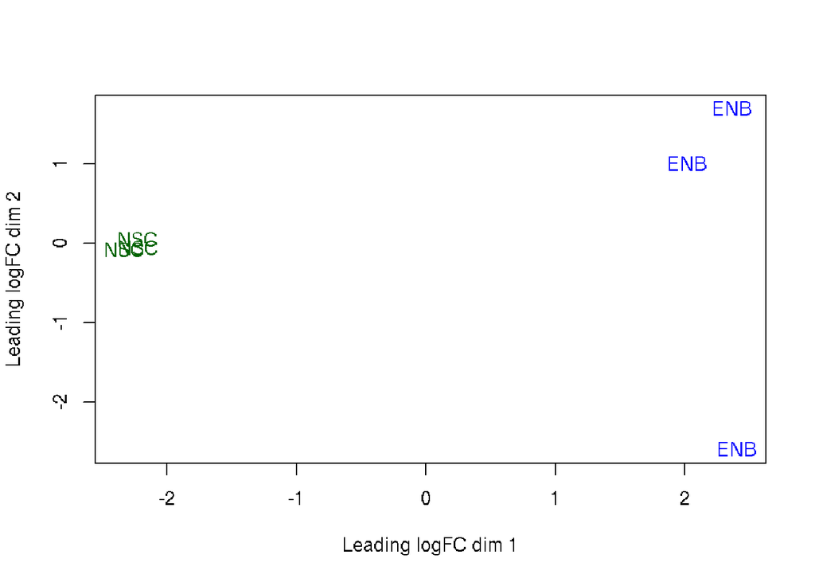

```r
plotMDS(y, labels=condition,
col=c("darkgreen","blue")[factor(condition)])
```

- Esta función calculará las distancias euclı́deas entre cada para de muestras y representará en un gráfico de 2 dimensiones cómo es la relación entre las muestras. * Podemos observar si en el experimento la separación entre condiciones es suficientemente robusta y cómo es la relación entre las réplicas.

## Dispersión

En edgeR podemos estimar la dispersión usando diferentes estrategias:

```r
yD <- estimateCommonDisp(y, verbose=TRUE)
```

```
## Disp = 0.15673 , BCV = 0.3959
```

```r
#coeficiente de variación biológica
```

- Tagwise: siempre hay que calcular primero la dispersión común:

```r
yD <- estimateTagwiseDisp(yD)
```

Se recomienda usar la función *estimateDisp()*, que estima *common dispersion* y *tagwise dispersions* en 1 solo paso:

```r
y <- estimateDisp(y, verbose=TRUE)
```

```
## Using classic mode.
```

```r
y$common.dispersion
```

```
## [1] 0.1566876
```

```r
sqrt(y$common.dispersion)
```

```
## [1] 0.3958379
```

```r
summary(y$trended.dispersion)
```

```
##    Min. 1st Qu.  Median    Mean 3rd Qu.    Max.
## 0.03572 0.05448 0.10692 0.21254 0.34583 0.64505
```

```r
summary(y$tagwise.dispersion)
```

```
##    Min. 1st Qu.  Median    Mean 3rd Qu.    Max.
## 0.01798 0.04499 0.09851 0.22898 0.28868 3.75346
```

Para analizar la nube de puntos gráficamente, podemos usar la función *plotBCV*

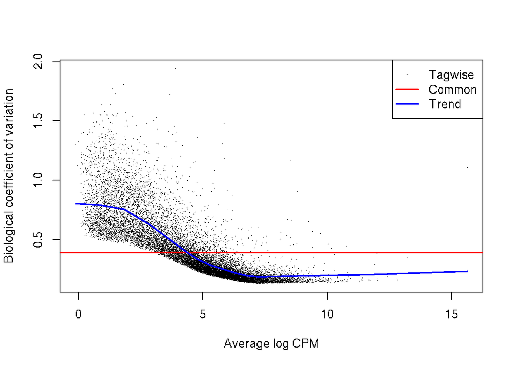

```r
plotBCV(y)
```

# Expresión diferencial

Ya estamos en condiciones de testear la expresión diferencial. Para ello **edegR** tiene la función *exactTest*. La misma necesitará la dispersión que acabamos de calcular y el par que queremos comparar. Este es un test que se utiliza para evaluar diferencias entre pares, bajo una distribución binomial negativa. Como resultado del test, obtenemos los *pvalues* para cada comparación. El resultado del test lo guardamos en un objeto nuevo **de**.

```r
de<-exactTest(y)
str(de)
```

```
## Formal class 'DGEExact' [package "edgeR"] with 1 slot
##   ..@ .Data:List of 3
##   .. ..$ :'data.frame':  13999 obs. of  3 variables:
##   .. .. ..$ logFC : num [1:13999] 0.957 -0.329 -0.422 -0.712 0.421 ...
##   .. .. ..$ logCPM: num [1:13999] 2.4 6.31 5.22 5.72 2.78 ...
##   .. .. ..$ PValue: num [1:13999] 0.33122 0.10049 0.12743 0.00295 0.46616 ...
##   .. ..$ : chr [1:2] "NSC" "ENB"
##   .. ..$ : NULL
```

```r
head(de)
```

```
## An object of class "DGEExact"
## $table
##                         logFC   logCPM       PValue
## ENSMUSG00000051951  0.9569622 2.396799 3.312198e-01
## ENSMUSG00000033845 -0.3291713 6.307627 1.004916e-01
## ENSMUSG00000025903 -0.4218527 5.216408 1.274300e-01
## ENSMUSG00000033813 -0.7119876 5.716240 2.948517e-03
## ENSMUSG00000062588  0.4210123 2.780811 4.661639e-01
## ENSMUSG00000002459 -2.5470092 6.312197 1.534428e-27
##
## $comparison
## [1] "NSC" "ENB"
```

¿Qué tenemos en el objeto **de**?

Con la función **topTags** se ordenarán los genes por su *pvalue* corregido. Por defecto se muestran los top 10:

```r
tt <- topTags(de)
tt
```

```
## Comparison of groups:  ENB-NSC
##                         logFC   logCPM        PValue           FDR
## ENSMUSG00000021702  -9.610167 7.036786 3.788906e-113 5.304090e-109
## ENSMUSG00000027875  -7.886081 7.172703  2.411728e-93  1.688089e-89
## ENSMUSG00000006522 -10.878799 5.853587  4.896235e-93  2.284746e-89
## ENSMUSG00000036480 -14.867911 7.842614  1.289325e-82  4.512316e-79
## ENSMUSG00000042988 -10.625284 5.595013  1.211074e-80  3.390765e-77
## ENSMUSG00000041556  -4.784167 6.792447  4.505736e-71  1.051263e-67
## ENSMUSG00000053398  -3.457831 8.471954  3.827383e-62  7.654218e-59
## ENSMUSG00000030772  -4.035029 8.606551  7.069648e-62  1.237100e-58
## ENSMUSG00000030605  -3.631474 9.545995  1.801103e-58  2.801516e-55
## ENSMUSG00000026247  -9.658406 6.342643  9.133318e-58  1.278573e-54
```

Pdemos extraer la cantidad de genes que especifiquemos, por ejemplo **TODOS** los genes testeados:

```r
tt <- topTags(de, n = nrow(de))
```

*¿Cuáles son los genes que están más afectado en este experimento? ¿Tiene lógica?*

Podemos explorar rápidamente cómo se distribuyeron los *pvalues*:

```r
summary(tt$table$FDR)
```

```
##    Min. 1st Qu.  Median    Mean 3rd Qu.    Max.
## 0.00000 0.01444 0.25429 0.35341 0.66209 1.00000
```

```r
table(tt$table$FDR <0.05)
```

```
##
## FALSE  TRUE
##  9460  4539
```

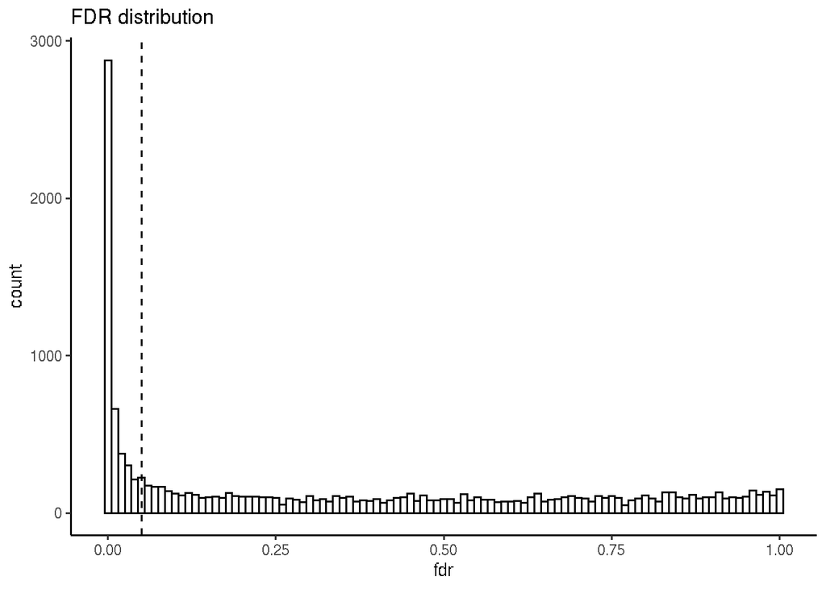

```r
df <- data.frame(
  exp="ENB",
  fdr=tt$table$FDR)
# Change colors
ggplot(df, aes(x=fdr)) +
geom_histogram(color="black", fill="white", binwidth=0.01)+
geom_vline(xintercept=0.05, linetype="dashed")+
theme_classic()+
labs(title="FDR distribution")
```

## MA plot

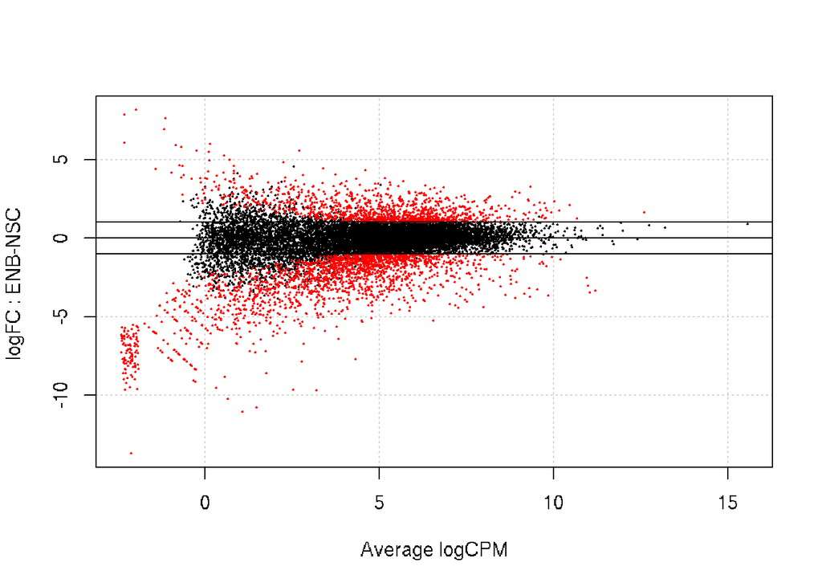

```r
deg<-rownames(tt)[tt$table$FDR <.05 &
                  abs(tt$table$logFC )>1 ]
plotSmear(y, de.tags=deg)
abline(h=c(-1,0,1))
```

## Vulcano plot (casi el último esfuerzo)

```r
ttable <-tt$table
dim(ttable)
```

```
## [1] 13999     4
```

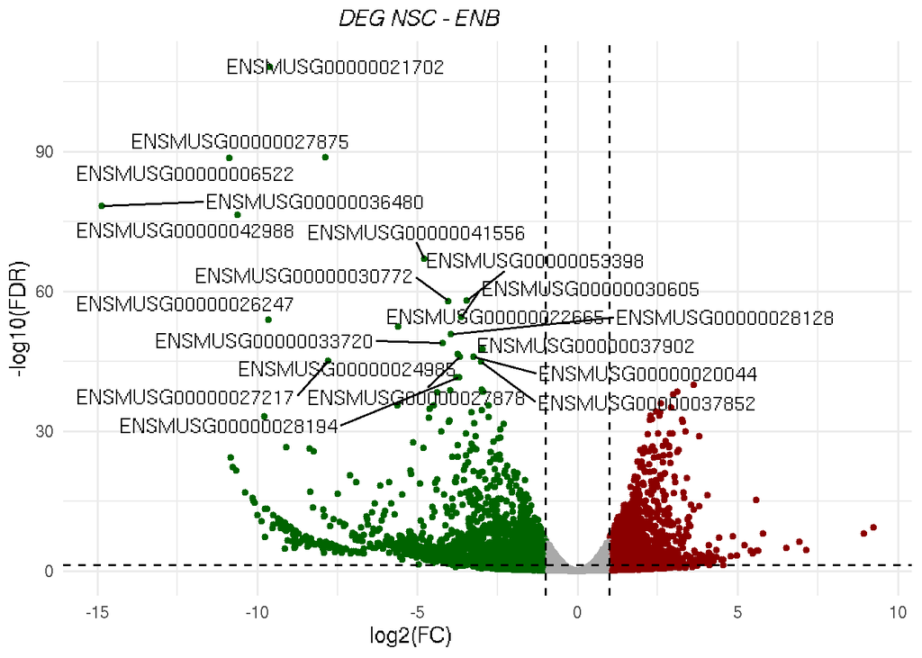

```r
tt10 <- topTags(de, n=20)

ttable$gene_color <- rep("grey", nrow(ttable))
ttable$gene_color[ttable$logFC>1] <-"red"
ttable$gene_color[ttable$logFC< (-1)]<-"green"
ttable$imp_genes<-NA

ii <- match(rownames(tt10), rownames(ttable))
ttable$imp_genes[ii]<-rownames(ttable)[ii]

ggplot(ttable, aes(x=logFC, y=-log10(FDR))) +
  geom_point(aes(col=gene_color), cex= 1.2) +
  scale_color_manual(values=c("dark green","dark grey", "dark red")) +
  labs(title="DEG NSC - ENB", x="log2(FC)", y="-log10(FDR)") +
  geom_vline(xintercept= c(-1, 1), colour= 'black', linetype= 'dashed') +
  geom_hline(yintercept= 1.30103, colour= 'black', linetype= 'dashed') +
  theme_minimal()+
  theme(legend.position = "none",
        plot.title = element_text(size = 12, face="italic", hjust=0.4),
        axis.title.x = element_text(color = "black", size=12, hjust = 0.4),
        axis.title.y = element_text(size =12, hjust = 0.5)) +
  geom_text_repel(data=ttable,
                  aes(x=logFC, y=-log10(FDR)),
                  label =ttable$imp_genes,
                  box.padding = unit(0.25, "lines"),
                  hjust =1,
                  max.overlaps = 50)
```

Exportamos los resultados en formato tabular, para futuros análisis:

```r
write.csv(tt$table, file="ENB_edgeR.csv")
tt500 <- topTags(de, n =500)
write.csv(tt500$table, file="top500_ENB_edgeR.csv")
```

## Un poquito más…

- Cambiamos el ensembl ID por el symbol. Vamos a usar los paquetes del paradigma: **org.XX.eg.db**
- Son muy prácticos para trabajar con Bioconductor

```r
MmuENS <- toTable(org.Mm.egENSEMBL2EG); head(MmuENS)
```

```
##   gene_id         ensembl_id
## 1   11287 ENSMUSG00000030359
## 2   11298 ENSMUSG00000020804
## 3   11302 ENSMUSG00000025375
## 4   11303 ENSMUSG00000015243
## 5   11304 ENSMUSG00000028125
## 6   11305 ENSMUSG00000026944
```

```r
MmuSYMBOL <- toTable(org.Mm.egSYMBOL); head(MmuSYMBOL)
```

```
##   gene_id symbol
## 1   11287    Pzp
## 2   11298  Aanat
## 3   11302   Aatk
## 4   11303  Abca1
## 5   11304  Abca4
## 6   11305  Abca2
```

- Agregamos Entrez Id:

```r
gi <- match(rownames(ttable), MmuENS$ensembl_id)
length(which(is.na(gi)))
```

```
## [1] 983
```

```r
ttable$ensemble_id <- rownames(ttable)
ttable$EntrezId <- MmuENS$gene_id[gi]
```

- Y symbol a nuestras tablas:

```r
si <- match(ttable$EntrezId, MmuSYMBOL$gene_id)
length(which(is.na(si)))#983
```

```
## [1] 983
```

```r
ttable$Symbol <- MmuSYMBOL$symbol[si]
head(ttable)
```

```
##                         logFC   logCPM        PValue           FDR gene_color
## ENSMUSG00000021702  -9.610167 7.036786 3.788906e-113 5.304090e-109      green
## ENSMUSG00000027875  -7.886081 7.172703  2.411728e-93  1.688089e-89      green
## ENSMUSG00000006522 -10.878799 5.853587  4.896235e-93  2.284746e-89      green
## ENSMUSG00000036480 -14.867911 7.842614  1.289325e-82  4.512316e-79      green
## ENSMUSG00000042988 -10.625284 5.595013  1.211074e-80  3.390765e-77      green
## ENSMUSG00000041556  -4.784167 6.792447  4.505736e-71  1.051263e-67      green
##                             imp_genes        ensemble_id EntrezId Symbol
## ENSMUSG00000021702 ENSMUSG00000021702 ENSMUSG00000021702    21828  Thbs4
## ENSMUSG00000027875 ENSMUSG00000027875 ENSMUSG00000027875    15360 Hmgcs2
## ENSMUSG00000006522 ENSMUSG00000006522 ENSMUSG00000006522    16426  Itih3
## ENSMUSG00000036480 ENSMUSG00000036480 ENSMUSG00000036480    69453 Prss56
## ENSMUSG00000042988 ENSMUSG00000042988 ENSMUSG00000042988    77583  Notum
## ENSMUSG00000041556 ENSMUSG00000041556 ENSMUSG00000041556   230904  Fbxo2
```

- Ahora podemos repetir el vulcano plot con el **symbol** como etiqueta:

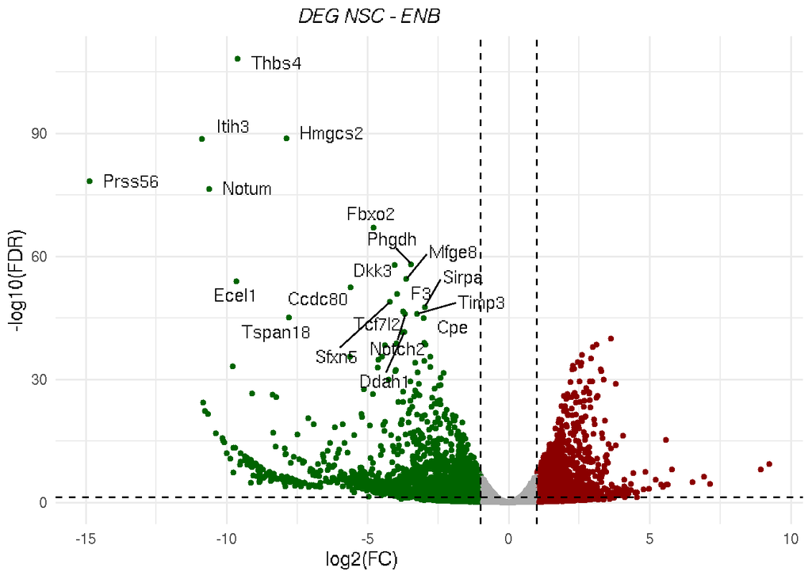

```r
ii <- match(rownames(tt10), rownames(ttable))
ttable$imp_genes[ii]<-ttable$Symbol[ii]

ggplot(ttable, aes(x=logFC, y=-log10(FDR))) +
  geom_point(aes(col=gene_color), cex= 1.2) +
  scale_color_manual(values=c("dark green","dark grey", "dark red")) +
  labs(title="DEG NSC - ENB", x="log2(FC)", y="-log10(FDR)") +
  geom_vline(xintercept= c(-1, 1), colour= 'black', linetype= 'dashed') +
  geom_hline(yintercept= 1.30103, colour= 'black', linetype= 'dashed') +
  theme_minimal()+
  theme(legend.position = "none",
        plot.title = element_text(size = 12, face="italic", hjust=0.4),
        axis.title.x = element_text(color = "black", size=12, hjust = 0.4),
        axis.title.y = element_text(size =12, hjust = 0.5)) +
  geom_text_repel(data=ttable,
                  aes(x=logFC, y=-log10(FDR)),
                  label =ttable$imp_genes,
                  box.padding = unit(0.25, "lines"),
                  hjust =1,
                  max.overlaps = 50)
```

## Gene Ontology

Podemos analizar enriquecimientos ontológicos de una forma muy sencilla:

- Primero hay que agregar EntrezID al objeto **de**:

```r
entrezi <- match(rownames(de), MmuENS$ensembl_id)
length(which(is.na(entrezi)))
```

```
## [1] 983
```

```r
de$ensemble_id <- rownames(de)
de$EntrezId <- MmuENS$gene_id[entrezi]
```

- Ahora vamos testeando, con diferentes opciones la lista de genes **de**
- Procesos Biológicos:

```r
go <- goana(de, species = "Mm", geneid=de$EntrezId)
topBPUp<-topGO(go, ont="BP", n=30, truncate=30, sort = "Up")
head(topBPUp)# enriquecimiento sobreexpresados
```

```
##                                      Term Ont    N   Up Down         P.Up
## GO:0030182         neuron differentiation  BP 1167  324  245 1.074108e-31
## GO:0007275 multicellular organism deve...  BP 3552  755  754 1.621921e-31
## GO:0050789 regulation of biological pr...  BP 7278 1333 1317 2.383412e-31
## GO:0031175 neuron projection developme...  BP  908  269  179 4.436451e-31
## GO:0048666             neuron development  BP 1001  288  203 6.697108e-31
## GO:0007399     nervous system development  BP 1809  446  403 7.214871e-31
##                  P.Down
## GO:0030182 1.503008e-02
## GO:0007275 1.263668e-06
## GO:0050789 9.436430e-01
## GO:0031175 1.901303e-01
## GO:0048666 8.081607e-02
## GO:0007399 1.025873e-05
```

```r
topBPDown<-topGO(go, ont="BP", n=30, truncate=30, sort = "Down")
head(topBPDown)
```

```
##                                      Term Ont    N Up Down      P.Up
## GO:0044281 small molecule metabolic pr...  BP 1186 91  394 1.0000000
## GO:0019752 carboxylic acid metabolic p...  BP  613 43  233 1.0000000
## GO:0006082 organic acid metabolic proc...  BP  656 45  243 1.0000000
## GO:0043436      oxoacid metabolic process  BP  646 44  237 1.0000000
## GO:0055114    oxidation-reduction process  BP  626 40  228 1.0000000
## GO:0032787 monocarboxylic acid metabol...  BP  378 25  151 0.9999999
##                  P.Down
## GO:0044281 4.049145e-37
## GO:0019752 3.855142e-31
## GO:0006082 1.828943e-30
## GO:0043436 5.414261e-29
## GO:0055114 2.211293e-27
## GO:0032787 6.920031e-23
```

- Función molecular (MF)

```r
topMF<-topGO(go, ont="MF", n=30, truncate=30)
head(topMF)
```

```
##                                      Term Ont    N   Up Down         P.Up
## GO:0016491        oxidoreductase activity  MF  514   38  193 1.000000e+00
## GO:0005515                protein binding  MF 6530 1139 1305 5.902454e-14
## GO:0005488                        binding  MF 9124 1505 1732 4.637628e-12
## GO:0140110 transcription regulator act...  MF 1231  270  161 1.354099e-11
## GO:0043565 sequence-specific DNA bindi...  MF 1075  241  137 2.080088e-11
## GO:0098772 molecular function regulato...  MF 2261  447  369 2.502574e-11
##                  P.Down
## GO:0016491 4.319883e-25
## GO:0005515 1.677054e-05
## GO:0005488 3.280519e-02
## GO:0140110 1.000000e+00
## GO:0043565 1.000000e+00
## GO:0098772 9.990030e-01
```

- Componentes celulares (CC)

```r
topCC<-topGO(go, ont="CC", n=30, truncate=30)
head(topCC)
```

```
##                            Term Ont    N   Up Down         P.Up       P.Down
## GO:0005576 extracellular region  CC  976  129  328 9.633620e-01 1.059814e-31
## GO:0005615  extracellular space  CC  575   63  222 9.987286e-01 8.149049e-31
## GO:0005739        mitochondrion  CC 1565  119  430 1.000000e+00 1.541219e-20
## GO:0005737            cytoplasm  CC 8271 1193 1718 9.983239e-01 3.181994e-18
## GO:0043005    neuron projection  CC 1142  278  228 6.767971e-18 1.098900e-01
## GO:0030424                 axon  CC  561  160   95 7.416496e-17 8.588933e-01
```

- Vías metabólicas usando KEGG:

```r
keg <- kegga(de, species="Mm",  geneid=de$EntrezId)
topKEGG(keg)
```

```
##                                                                Pathway    N Up
## path:mmu01100                                       Metabolic pathways 1140 91
## path:mmu01200                                        Carbon metabolism   96  4
## path:mmu01230                              Biosynthesis of amino acids   60  2
## path:mmu04550 Signaling pathways regulating pluripotency of stem cells   98 38
## path:mmu00620                                      Pyruvate metabolism   35  2
## path:mmu00640                                    Propanoate metabolism   28  0
## path:mmu00330                          Arginine and proline metabolism   37  2
## path:mmu00280               Valine, leucine and isoleucine degradation   49  3
## path:mmu01240                                Biosynthesis of cofactors  109  5
## path:mmu00010                             Glycolysis / Gluconeogenesis   44  3
## path:mmu01212                                    Fatty acid metabolism   55  1
## path:mmu00270                       Cysteine and methionine metabolism   40  3
## path:mmu00983                          Drug metabolism - other enzymes   43  2
## path:mmu00630                  Glyoxylate and dicarboxylate metabolism   28  1
## path:mmu03320                                   PPAR signaling pathway   46  1
## path:mmu00260                 Glycine, serine and threonine metabolism   32  0
## path:mmu00480                                   Glutathione metabolism   47  5
## path:mmu04360                                            Axon guidance  157 46
## path:mmu04068                                   FoxO signaling pathway  109 35
## path:mmu05200                                       Pathways in cancer  383 70
##               Down         P.Up       P.Down
## path:mmu01100  383 1.000000e+00 3.258323e-37
## path:mmu01200   53 9.998641e-01 8.930348e-16
## path:mmu01230   33 9.993885e-01 2.777295e-10
## path:mmu04550   27 9.081800e-09 1.862369e-02
## path:mmu00620   22 9.768505e-01 9.099097e-09
## path:mmu00640   19 1.000000e+00 1.486023e-08
## path:mmu00330   22 9.825161e-01 3.923844e-08
## path:mmu00280   26 9.848905e-01 5.848950e-08
## path:mmu01240   44 9.998846e-01 9.096669e-08
## path:mmu00010   24 9.716034e-01 9.426185e-08
## path:mmu01212   27 9.998814e-01 2.658851e-07
## path:mmu00270   22 9.536300e-01 2.665210e-07
## path:mmu00983   23 9.925636e-01 2.810144e-07
## path:mmu00630   17 9.899155e-01 9.360099e-07
## path:mmu03320   23 9.994778e-01 1.351237e-06
## path:mmu00260   18 1.000000e+00 2.125869e-06
## path:mmu00480   23 8.587254e-01 2.182834e-06
## path:mmu04360   30 4.063481e-06 4.639000e-01
## path:mmu04068   17 6.209481e-06 8.221474e-01
## path:mmu05200  106 4.950618e-02 6.273776e-06
```

- gProfiler:

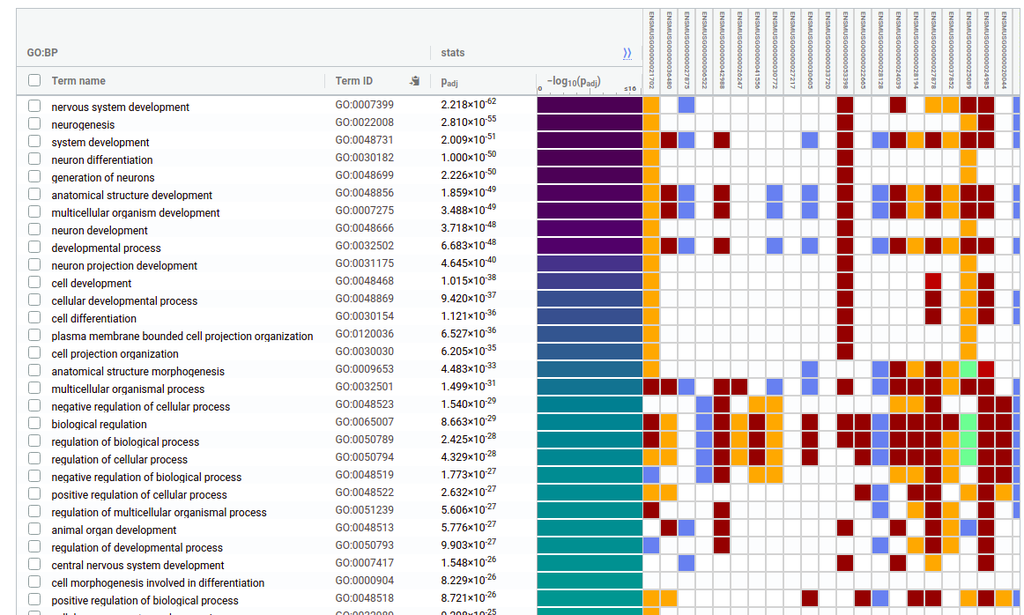